# Read Homer Output Analysis - For Null

Can you pull out a couple examples of TFs (maybe 1 or 2) from these 73K and identify which part of the motif is affected by the SNP? I bet it will be the part of a motif where there is a very heavy weight on one particular nucleotide and messing that up results in failure to identify the motif with the alternative allele.

also, could you show one or two examples of TFs from the 69K set, where searching the reference genome fails to identify a motif but searching with the alternative allele finds it?

Similarly, I bet the SNPs occur in the super important core part of the motif with high probabilities (from the PWM) for that nucleotide. Do you have experience making sequence logos? they’re fun plots to show the important of each nucleotide in a motif?

Limitations: only looks at positive strand

`r`r # source(://bioconductor.org/biocLite.R) # BiocManager::install() library(seqLogo) # makePWM library(stringr) # read.fasta, write.fasta library(data.table) library(dplyr) library(glue) library(matrixStats)

`r`r # in_ref_not_alt_unique_SNP <- fread(/Users/kathryntsai/OneDrive - Villanova University/College/2018-2019/Summer 2019/TFs_eQTLs_Research/RProjects/Project2/q2_3_output/in_ref_not_alt_unique_SNP.txt) # 264905 x 8 # in_alt_not_ref_unique_SNP <- fread(/Users/kathryntsai/OneDrive - Villanova University/College/2018-2019/Summer 2019/TFs_eQTLs_Research/RProjects/Project2/q2_3_output/in_alt_not_ref_unique_SNP.txt) # 269853 x 8 # # x1 <- in_ref_not_alt_unique_SNP[!duplicated(in_ref_not_alt_unique_SNP),] # 70550 x 8 # x2 <- in_alt_not_ref_unique_SNP[!duplicated(in_alt_not_ref_unique_SNP),] # 72078 x 8 # #in_ref_not_alt_unique_SNP$ref_Offset <- in_ref_not_alt_unique_SNP$ref_Offset + 21 #in_alt_not_ref_unique_SNP$alt_Offset <- in_alt_not_ref_unique_SNP$alt_Offset + 21 a_gene_snp <- fread(/Users/kathryntsai/OneDrive - Villanova University/College/2018-2019/Summer 2019/TFs_eQTLs_Research/RProjects/Project2/q2_3_output/a_gene_snp.txt) # 925540 x 14

[output not shown]

[output not shown]

[output not shown]

Using only motifs on positive strands, sort motifs by Motif Score Change # data points with value of n in z_test_group

`r`r x1_s <- x1[!duplicated(x1$Name), ] # 423 x8 x2_s <- x2[!duplicated(x2$Name), ] # 422 x 8 # z <- inner_join(x1_s[x1_s$_Strand == +,], x2_s[x2_s$_Strand == +,], by=Name) # 925540 x 9 z <- x1_s[x1_s$_Strand == +,] z_test_group_ref <- z[order(z$_MotifScore, decreasing=F),] # z_test_group_ref <- tail(z[order(z$_MotifScore, decreasing=F),], n=126L) # 237 x 15 #z_test_group$alt_Offset <- z_test_group$alt_Offset + 21 #z_test_group$ref_Offset <- z_test_group$ref_Offset + 21 z <- x2_s[x2_s$_Strand == +,] z_test_group_alt <- z[order(z$_MotifScore, decreasing=F),] # z_test_group_alt <- tail(z[order(z$_MotifScore, decreasing=F),], n=215L) # 215 x 15

`r`r ref_test_group <- x1_s[x1_s$\Motif Name\ %in% z_test_group_ref$Name] # 237 x 8 alt_test_group <- x2_s[x2_s$\Motif Name\ %in% z_test_group_alt$Name] # 215 x 8 # Note: ref_test_group[1,Name] != ref_test_group$`Motif Name`[1]

Todo: detect # motifs without hardcoding it in

`r`r

ref_test_group_file <- left_join(ref_test_group, motifs_table) # 11 x 9

```
Column `Motif Name` joining character vector and factor, coercing into character vector
```

`r`r ref_test_group_file$ref_Offset <- ref_test_group_file$ref_Offset + 21 ref_test_group_file$SNPPosInFasta <- 0.001 ref_test_group_with_fasta <- merge(ref_test_group, a_gene_snp) # also by 'SNP' ref_test_group_with_fasta$ref_Offset <- ref_test_group_with_fasta$ref_Offset+21 ref_test_group_with_fasta <- ref_test_group_with_fasta[which(str_sub(ref_test_group_with_fasta$fasta_seq_og, 21, 21) == ref_test_group_with_fasta$OtherAllele), ] # 37x20, only necessary if you didn’t use old a_gene_snp file for homer input counter_of_excluded_data <- 0 library(matrixStats)

`r`r

i=1

## make_PWM_and_get_motif_sequence_for_1_motif

impt_table <- read.table(paste(/Users/kathryntsai/OneDrive - Villanova University/College/2018-2019/Summer 2019/TFs_eQTLs_Research/RProjects/Project2/q2_3_investigation/motifs/motif, ref_test_group_file[i,], .motif, sep=\), sep=\t, skip=1, header=F, stringsAsFactors=FALSE) colnames(impt_table) <- c(, , , ) max_TF_motifs <- data.frame(cbind(data.frame(rowMaxs(as.matrix(impt_table), cols=T)), 1:nrow(impt_table), colnames(impt_table)[apply(impt_table,1,which.max)])) colnames(max_TF_motifs) <- c(, , ) tf_motif <- paste(max_TF_motifs$Base, collapse=\, sep=\)

## get_fasta_seq_and_get_rid_of_matches_that_do_not_work: Where does the SNP hit the TF? for alt_test_group: I think eQTLGen is zero-indexed.

## see_where_TF_hits_fasta_seq

motif_w_fasta_seq_info <- ref_test_group_with_fasta[which(ref_test_group_with_fasta$Name == ref_test_group_file[i,Name]),] motif_w_fasta_seq_info <- motif_w_fasta_seq_info[1,] # only need first row for fasta seq

## does_TF_hit_SNP_if_so_get_position

if (motif_w_fasta_seq_info$ref_Offset[i] >= (21 - nchar(tf_motif)) & motif_w_fasta_seq_info$ref_Offset != 21) { ref_test_group_file$SNPPosInFasta[i] <- 21 - ref_test_group_file$ref_Offset[i] all_snp_pwms_ref <- max_TF_motifs[21 - motif_w_fasta_seq_info$ref_Offset[i], ] # make this rbind later all_snp_pwms_ref <- cbind(all_snp_pwms_ref, i) # make this cbind later } else { all_snp_pwms_ref <- data.table(NA, NA, NA, i) # to begin colnames(all_snp_pwms_ref) <- c(, , , ) counter_of_excluded_data <- counter_of_excluded_data + 1 }

for (i in 2:nrow(ref_test_group_file)){ impt_table <- read.table(paste(/Users/kathryntsai/OneDrive - Villanova University/College/2018-2019/Summer 2019/TFs_eQTLs_Research/RProjects/Project2/q2_3_investigation/motifs/motif, ref_test_group_file[i,], .motif, sep=\), sep=\t, skip=1, header=F, stringsAsFactors=FALSE) colnames(impt_table) <- c(, , , ) max_TF_motifs <- data.frame(cbind(data.frame(rowMaxs(as.matrix(impt_table), cols=T)), 1:nrow(impt_table), colnames(impt_table)[apply(impt_table,1,which.max)])) colnames(max_TF_motifs) <- c(, , ) tf_motif <- paste(max_TF_motifs$Base, collapse=\, sep=\) # CATGCATATGCATAT

## get_fasta_seq_and_get_rid_of_matches_that_do_not_work: Where does the SNP hit the TF? for ref_test_group: I think eQTLGen is zero-indexed.

## see_where_TF_hits_fasta_seq motif_w_fasta_seq_info <- ref_test_group_file[which(ref_test_group_file$Name == ref_test_group_file[i,Name]),] motif_w_fasta_seq_info <- motif_w_fasta_seq_info[1,] # only need first row for fasta seq

## does_TF_hit_SNP_if_so_get_position # plot(max_TF_motifs$Num) if (motif_w_fasta_seq_info$ref_Offset[1] > (21 - nchar(tf_motif)) & motif_w_fasta_seq_info$ref_Offset != 21) # if offset = 21, skip this { ref_test_group_file$SNPPosInFasta[i] <- 21 - motif_w_fasta_seq_info$ref_Offset[1] row_to_bind <- data.frame(max_TF_motifs[21 - motif_w_fasta_seq_info$ref_Offset[1], ], i) all_snp_pwms_ref <- rbind(all_snp_pwms_ref, row_to_bind) } else { counter_of_excluded_data <- counter_of_excluded_data + 1 } }

all_snp_pwms_ref <- all_snp_pwms_ref[!is.na(all_snp_pwms_ref$Num),]

`r`r # hist(all_snp_pwms$Num) # all_snp_pwms %>% count(Num) # mean = blue dashed line, density plot = red transparent ggplot(all_snp_pwms_ref, aes(x=as.numeric(Num))) + #stat_count() + geom_histogram(binwidth=.1, color=\black\, fill=\blue\) + #y_lim(0, 4) #xlim(0, 1)+ #geom_text(aes(label=Base), hjust=2, vjust=1) + #geom_point(data = max_TF_motifs[21 - ref_test_group_with_fasta$ref_Offset[1],], x=Index, y = Num) + theme_stata() + geom_density(alpha=.2, fill=#FF6666, aes(y=..count../8)) + geom_vline(aes(xintercept=mean(as.numeric(Num))), color=, linetype=, size=1) + ggtitle(of All Motifs - Reference Allele)

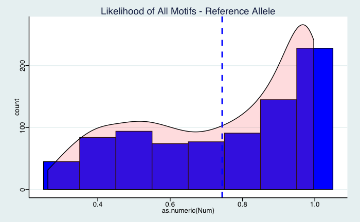

For alt

`r`r alt_test_group_file <- left_join(alt_test_group, motifs_table) # 11 x 9

```
Column `Motif Name` joining character vector and factor, coercing into character vector
```

`r`r alt_test_group_file$alt_Offset <- alt_test_group_file$alt_Offset + 21 alt_test_group_file$SNPPosInFasta <- 0.001 alt_test_group_with_fasta <- merge(alt_test_group, a_gene_snp) # also by 'SNP' alt_test_group_with_fasta$alt_Offset <- alt_test_group_with_fasta$alt_Offset+21 alt_test_group_with_fasta <- alt_test_group_with_fasta[which(str_sub(alt_test_group_with_fasta$fasta_seq_og, 21, 21) == alt_test_group_with_fasta$OtherAllele), ] # 37x20, only necessary if you didn’t use old a_gene_snp file for homer input counter_of_excluded_data <- 0

`r`r i=1 ## make_PWM_and_get_motif_sequence_for_1_motif impt_table <- read.table(paste(/Users/kathryntsai/OneDrive - Villanova University/College/2018-2019/Summer 2019/TFs_eQTLs_Research/RProjects/Project2/q2_3_investigation/motifs/motif, alt_test_group_file[i,], .motif, sep=\), sep=\t, skip=1, header=F, stringsAsFactors=FALSE) colnames(impt_table) <- c(, , , ) max_TF_motifs <- data.frame(cbind(data.frame(rowMaxs(as.matrix(impt_table), cols=T)), 1:nrow(impt_table), colnames(impt_table)[apply(impt_table,1,which.max)])) colnames(max_TF_motifs) <- c(, , ) tf_motif <- paste(max_TF_motifs$Base, collapse=\\, sep=\\) ## get_fasta_seq_and_get_rid_of_matches_that_do_not_work: Where does the SNP hit the TF? for alt_test_group: I think eQTLGen is zero-indexed. ## see_where_TF_hits_fasta_seq motif_w_fasta_seq_info <- alt_test_group_with_fasta[which(alt_test_group_with_fasta$Name == alt_test_group_file[i,Name]),] motif_w_fasta_seq_info <- motif_w_fasta_seq_info[1,] # only need first row for fasta seq ## does_TF_hit_SNP_if_so_get_position if (motif_w_fasta_seq_info$alt_Offset[i] >= (21 - nchar(tf_motif)) & motif_w_fasta_seq_info$alt_Offset != 21) { alt_test_group_file$SNPPosInFasta[i] <- 21 - alt_test_group_file$alt_Offset[i] all_snp_pwms_alt <- max_TF_motifs[21 - motif_w_fasta_seq_info$alt_Offset[i], ] # make this rbind later all_snp_pwms_alt <- cbind(all_snp_pwms_alt, i) # make this cbind later } else { all_snp_pwms_alt <- data.table(NA, NA, NA, i) # to begin colnames(all_snp_pwms_alt) <- c(, , , ) counter_of_excluded_data <- counter_of_excluded_data + 1 }

for (i in 2:nrow(alt_test_group_file)){ impt_table <- read.table(paste(/Users/kathryntsai/OneDrive - Villanova University/College/2018-2019/Summer 2019/TFs_eQTLs_Research/RProjects/Project2/q2_3_investigation/motifs/motif, alt_test_group_file[i,], .motif, sep=\), sep=\t, skip=1, header=F, stringsAsFactors=FALSE) colnames(impt_table) <- c(, , , ) max_TF_motifs <- data.frame(cbind(data.frame(rowMaxs(as.matrix(impt_table), cols=T)), 1:nrow(impt_table), colnames(impt_table)[apply(impt_table,1,which.max)])) colnames(max_TF_motifs) <- c(, , ) tf_motif <- paste(max_TF_motifs$Base, collapse=\, sep=\) # CATGCATATGCATAT

## get_fasta_seq_and_get_rid_of_matches_that_do_not_work: Where does the SNP hit the TF? for alt_test_group: I think eQTLGen is zero-indexed.

## see_where_TF_hits_fasta_seq motif_w_fasta_seq_info <- alt_test_group_file[which(alt_test_group_file$Name == alt_test_group_file[i,Name]),] motif_w_fasta_seq_info <- motif_w_fasta_seq_info[1,] # only need first row for fasta seq

## does_TF_hit_SNP_if_so_get_position # plot(max_TF_motifs$Num) if (motif_w_fasta_seq_info$alt_Offset[1] > (21 - nchar(tf_motif)) & motif_w_fasta_seq_info$alt_Offset != 21) # if offset = 21, skip this { alt_test_group_file$SNPPosInFasta[i] <- 21 - motif_w_fasta_seq_info$alt_Offset[1] row_to_bind <- data.frame(max_TF_motifs[21 - motif_w_fasta_seq_info$alt_Offset[1], ], i) all_snp_pwms_alt <- rbind(all_snp_pwms_alt, row_to_bind) } else { counter_of_excluded_data <- counter_of_excluded_data + 1 } } all_snp_pwms_alt <- all_snp_pwms_alt[!is.na(all_snp_pwms_alt$Num),]

`r`r # hist(all_snp_pwms$Num) # all_snp_pwms %>% count(Num) # mean = blue dashed line, density plot = red transparent ggplot(all_snp_pwms_alt, aes(x=as.numeric(Num))) + geom_histogram(binwidth=.1, color=, fill=) + theme_stata() + geom_density(alpha=.2, fill=#FF6666, aes(y=..count../8)) + geom_vline(aes(xintercept=mean(as.numeric(Num))), color=, linetype=, size=1) + ggtitle(of Interesting Motifs - Alternative Allele)

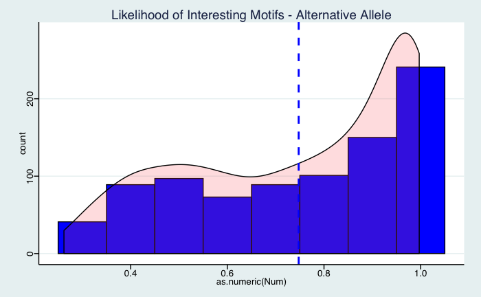

`r`r all_homer <- rbind(all_snp_pwms_alt, all_snp_pwms_ref) ggplot(all_homer, aes(x=as.numeric(Num))) + geom_histogram(binwidth=.1, color=, fill=) + theme_stata() + geom_density(alpha=.2, fill=#FF6666, aes(y=..count../8)) + geom_vline(aes(xintercept=mean(as.numeric(Num))), color=, linetype=, size=1) + ggtitle(of All Motifs - Ref/Alt Allele)

```
Error in theme_stata() : could not find function \theme_stata\
```

[output not shown]